# Can we predict a student's likelihood of experiencing depression based on various factors such as academic pressure, sleep duration, dietary habits, family mental health history, CGPA, and other socio-environmental variables?

# Dataset Description

The dataset provides information about various students, including demographic details, lifestyle habits, and mental health indicators. The data is primarily used for predicting depression in students based on various factors like academic pressure, work pressure, sleep duration, and family history of mental illness. Each row represents a student, with their attributes and mental health status.

# Explanation of Columns

id: A unique identifier for each student (numeric). Gender: The gender of the student (Male/Female). Age: The age of the student (numeric). City: The city where the student resides (categorical). Profession: The student’s profession or role (typically "Student" in this dataset). Academic Pressure: A rating (1-5) representing how much academic pressure the student feels. Work Pressure: A rating (0-5) representing how much work pressure the student feels. CGPA: The student’s CGPA or Grade Point Average (numeric). Study Satisfaction: A rating (1-5) indicating how satisfied the student is with their studies. Job Satisfaction: A rating (0-5) indicating how satisfied the student is with their job (if applicable). Sleep Duration: The average number of hours the student sleeps each night (Less than 5 hours, 5-6 hours, 7-8 hours, More than 8 hours). Dietary Habits: The student’s dietary habits (Healthy, Moderate, Unhealthy). Degree: The degree the student is pursuing (e.g., B.Pharm, B.Ed, MSc, etc.). Have you ever had suicidal thoughts?: A binary indicator of whether the student has ever had suicidal thoughts (Yes/No). Work/Study Hours: The number of hours the student spends on work or study activities. Financial Stress: A rating (1-5) representing how much financial stress the student feels. Family History of Mental Illness: Indicates whether the student has a family history of mental illness (Yes/No). Depression: The target variable indicating whether the student is depressed (1 for depressed, 0 for not depressed).

# IMPORT LIBRARIES

```python
import pandas as pd
import numpy as np
```

```python
import matplotlib.pyplot as plt
import seaborn as sns
```

# LOADING THE STUDENT DEPRESSION DATASET

```python
Depression = pd.read_csv(r"C:\Users\manna\OneDrive\Documents\Students Depression.csv")
```

# Check out the info(), head() abd description() on the depression dataset

```python
Depression.info()
```

```
<class 'pandas.core.frame.DataFrame'>
RangeIndex: 27901 entries, 0 to 27900
Data columns (total 18 columns):
 #   Column                                 Non-Null Count  Dtype
---  ------                                 --------------  -----
 0   id                                     27901 non-null  int64
 1   Gender                                 27901 non-null  object
 2   Age                                    27901 non-null  int64
 3   City                                   27901 non-null  object
 4   Profession                             27901 non-null  object
 5   Academic Pressure                      27901 non-null  int64
 6   Work Pressure                          27901 non-null  int64
 7   CGPA                                   27901 non-null  float64
 8   Study Satisfaction                     27901 non-null  int64
 9   Job Satisfaction                       27901 non-null  int64
 10  Sleep Duration                         27901 non-null  object
 11  Dietary Habits                         27901 non-null  object
 12  Degree                                 27901 non-null  object
 13  Have you ever had suicidal thoughts ?  27901 non-null  object
 14  Work/Study Hours                       27901 non-null  int64
 15  Financial Stress                       27898 non-null  float64
 16  Family History of Mental Illness       27901 non-null  object
 17  Depression                             27901 non-null  int64
dtypes: float64(2), int64(8), object(8)
memory usage: 3.8+ MB
```

```python
Depression.describe()
```

|  | id | Age | Academic Pressure | Work Pressure | CGPA | Study Satisfaction | Job Satisfaction | Work/Study Hours | Financial Stress | Depression |
| --- | --- | --- | --- | --- | --- | --- | --- | --- | --- | --- |
| count | 27901.000000 | 27901.000000 | 27901.000000 | 27901.000000 | 27901.000000 | 27901.000000 | 27901.000000 | 27901.000000 | 27898.000000 | 27901.000000 |
| mean | 70442.149421 | 25.822300 | 3.141214 | 0.000430 | 7.656104 | 2.943837 | 0.000681 | 7.156984 | 3.139867 | 0.585499 |
| std | 40641.175216 | 4.905687 | 1.381465 | 0.043992 | 1.470707 | 1.361148 | 0.044394 | 3.707642 | 1.437347 | 0.492645 |
| min | 2.000000 | 18.000000 | 0.000000 | 0.000000 | 0.000000 | 0.000000 | 0.000000 | 0.000000 | 1.000000 | 0.000000 |
| 25% | 35039.000000 | 21.000000 | 2.000000 | 0.000000 | 6.290000 | 2.000000 | 0.000000 | 4.000000 | 2.000000 | 0.000000 |
| 50% | 70684.000000 | 25.000000 | 3.000000 | 0.000000 | 7.770000 | 3.000000 | 0.000000 | 8.000000 | 3.000000 | 1.000000 |
| 75% | 105818.000000 | 30.000000 | 4.000000 | 0.000000 | 8.920000 | 4.000000 | 0.000000 | 10.000000 | 4.000000 | 1.000000 |
| max | 140699.000000 | 59.000000 | 5.000000 | 5.000000 | 10.000000 | 5.000000 | 4.000000 | 12.000000 | 5.000000 | 1.000000 |

```python
 Depression.head(2)
```

|  | id | Gender | Age | City | Profession | Academic Pressure | Work Pressure | CGPA | Study Satisfaction | Job Satisfaction | Sleep Duration | Dietary Habits | Degree | Have you ever had suicidal thoughts ? | Work/Study Hours | Financial Stress | Family History of Mental Illness | Depression |
| --- | --- | --- | --- | --- | --- | --- | --- | --- | --- | --- | --- | --- | --- | --- | --- | --- | --- | --- |
| 0 | 2 | Male | 33 | Visakhapatnam | Student | 5 | 0 | 8.97 | 2 | 0 | 5-6 hours | Healthy | B.Pharm | Yes | 3 | 1.0 | No | 1 |
| 1 | 8 | Female | 24 | Bangalore | Student | 2 | 0 | 5.90 | 5 | 0 | 5-6 hours | Moderate | BSc | No | 3 | 2.0 | Yes | 0 |

# EXPLORATORY DATA ANALYSIS (EDA)

```python
def pattern_missing(self):
    # Create a DataFrame to track missing value patterns
    missing_patterns = self.isna().astype(int).astype(str).agg('-'.join, axis=1)
    pattern_counts = missing_patterns.value_counts().sort_index()
    patterns_df = pattern_counts.reset_index()
    patterns_df.columns = ['Pattern', 'Count']

    # Convert the pattern to a list of binary missing values
    patterns_df['Pattern'] = patterns_df['Pattern'].apply(lambda x: [int(val) for val in x.split('-')])

    # Calculate how many features are missing in each pattern
    patterns_df['Missing_Features'] = patterns_df['Pattern'].apply(lambda x: sum(x))

    # Count missing values per column
    missing_counts = self.isna().sum()

    # Reorder rows by frequency of missing value combinations
    patterns_df = patterns_df.sort_values(by='Count', ascending=False).reset_index(drop=True)

    # Calculate the sum of all missing values
    sum_missing_counts = missing_counts.sum()

    # Prepare the data for plotting
    pattern_matrix = np.zeros((len(patterns_df), len(self.columns)))
    for i, pattern in enumerate(patterns_df['Pattern']):
        pattern_matrix[i, :] = pattern

    # Create the plot
    fig, ax1 = plt.subplots(figsize=(12, 8))  # Adjust size as necessary
    sns.heatmap(pattern_matrix, cmap="Accent", cbar=False, ax=ax1,
                xticklabels=False, yticklabels=False, linecolor='black', linewidth=1)

    # Set ticks for the main x-axis
    ax1.set_xticks(np.arange(len(self.columns)) + 0.5)
    ax1.set_xticklabels([str(count) for count in missing_counts], ha='center', fontsize=15)
    ax1.xaxis.set_label_position('bottom')
    ax1.xaxis.set_ticks_position('bottom')
    ax1.tick_params(which='both', length=0, pad=15)  # Remove ticks

    # Add the sum label to the bottom right corner
    ax1.text(len(self.columns) + 0.5, pattern_matrix.shape[0] + 0.5,
             f'{sum_missing_counts}', va='center', ha='center', fontsize=15)

    # Add feature labels along the top by twinning the x-axis
    ax2 = ax1.twiny()
    ax2.set_xlim(ax1.get_xlim())  # Align x-limits with ax1
    ax2.set_xticks(ax1.get_xticks())  # Align ticks with ax1
    ax2.set_xticklabels(self.columns, ha='center', fontsize=15, rotation=90)
    ax2.xaxis.set_label_position('top')
    ax2.xaxis.set_ticks_position('top')
    ax2.tick_params(axis='x', which='major', pad=15)

    # Remove the top spine and ticks for the twinned axis
    ax2.spines['top'].set_visible(False)
    ax2.spines['bottom'].set_visible(False)
    ax2.tick_params(which='both', length=0)  # Remove ticks

    # Add row labels on the left and right, centered
    ax1.set_yticks(np.arange(len(patterns_df)) + 0.5)
    ax1.set_yticklabels(patterns_df['Count'], va='center', ha='center', position=(-0.03, 0.5), fontsize=15)

    # Add labels along the right to count how many missing features belong to that combination
    for i, count in enumerate(patterns_df['Missing_Features']):
        ax1.text(len(self.columns) + 0.4, i + 0.5, str(count), va='center', ha='left', fontsize=15)

    plt.show()

# Add the method to pandas DataFrame
pd.DataFrame.pattern_missing = pattern_missing
```

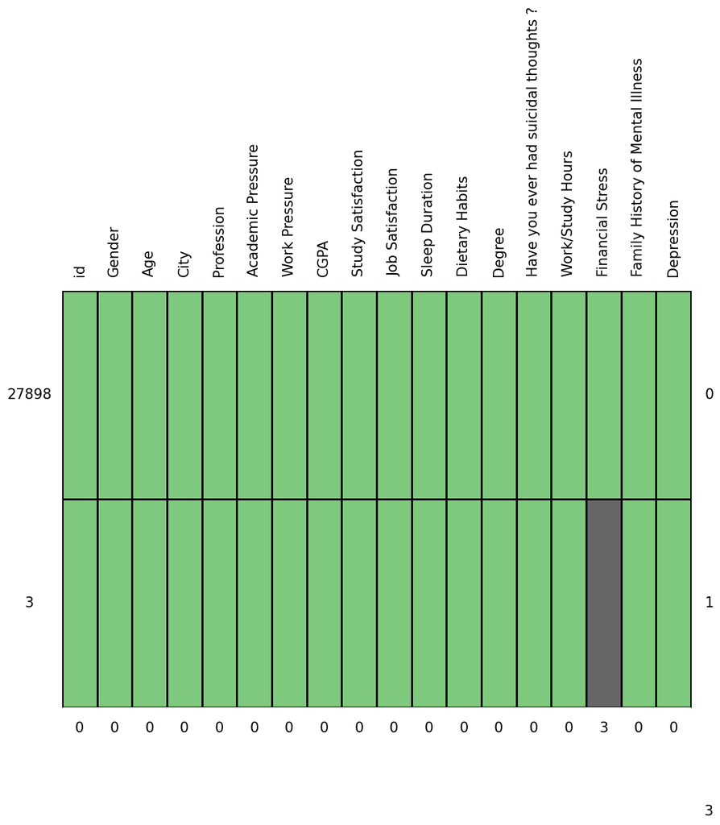

```python
Depression.pattern_missing()
```

```python
Depression['Financial Stress'] = Depression['Financial Stress'].fillna(Depression['Financial Stress'].mode()[0])
```

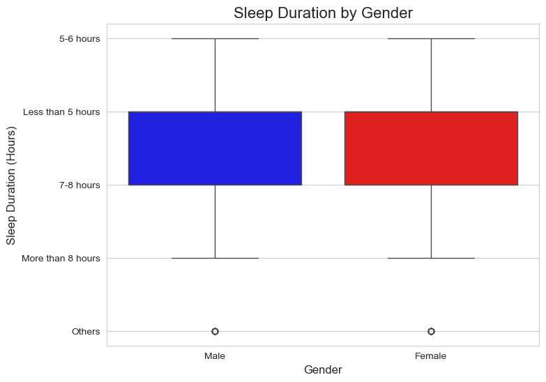

```python
# Create a boxplot to compare Sleep Duration across Gender groups.
# Set the style for a clean background
sns.set_style('whitegrid')

# Define a custom color palette for genders
gender_colors = {"Male": "blue", "Female": "red"}

# Create the boxplot with 'hue' and custom colors
plt.figure(figsize=(8, 6))
sns.boxplot(
    x=Depression['Gender'],
    y=Depression['Sleep Duration'],
    hue=Depression['Gender'],  # Assign 'Gender' to hue
    palette=gender_colors,
    dodge=False  # Ensures boxes for the same category are merged
)

# Add a title and customize font size
plt.title('Sleep Duration by Gender', fontsize=16)

# Customize x and y axis labels
plt.xlabel('Gender', fontsize=12)
plt.ylabel('Sleep Duration (Hours)', fontsize=12)

# Show the plot
plt.show()
```

The boxplot shows that the median sleep duration for both men and women is the same, indicating no significant difference between genders. Additionally, the range of common sleep durations (IQR) is identical for both groups. The "other" category appears as an outlier, likely due to rare or unusual sleep patterns, irregular schedules, or possible data entry issues. Overall, this suggests that gender does not strongly influence reported sleep durations in this dataset.

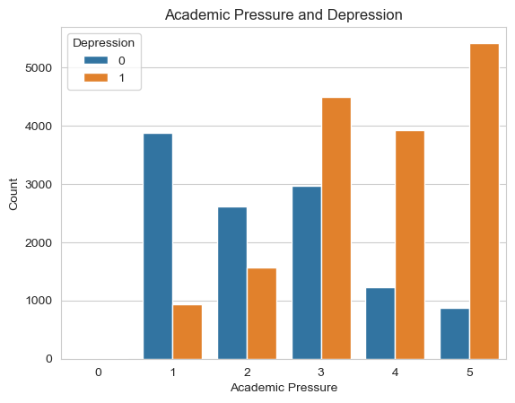

```python
# Bar plot for Academic Pressure vs Depression
sns.countplot(data=Depression, x='Academic Pressure', hue='Depression')
plt.title('Academic Pressure and Depression')
plt.xlabel('Academic Pressure')
plt.ylabel('Count')
plt.legend(title='Depression')
plt.show()
```

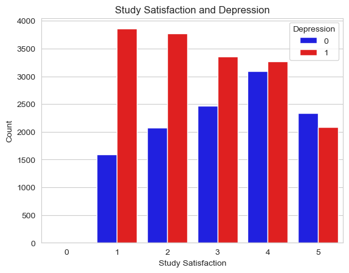

```python
import seaborn as sns
import matplotlib.pyplot as plt

# Custom color palette (you can replace with any color you prefer)
custom_palette = {0: 'blue', 1: 'red'}

# Bar plot with custom colors
sns.countplot(data=Depression, x='Study Satisfaction', hue='Depression', palette=custom_palette)
plt.title('Study Satisfaction and Depression')
plt.xlabel('Study Satisfaction')
plt.ylabel('Count')
plt.legend(title='Depression')
plt.show()
```

As study satisfaction increases, depression rates decrease. Students who report low satisfaction (levels 0-1) have a higher rate of depression. In contrast, students with higher study satisfaction (levels 4-5) show lower depression rates, although there are still some affected. This suggests that higher study satisfaction is linked to better mental well-being.

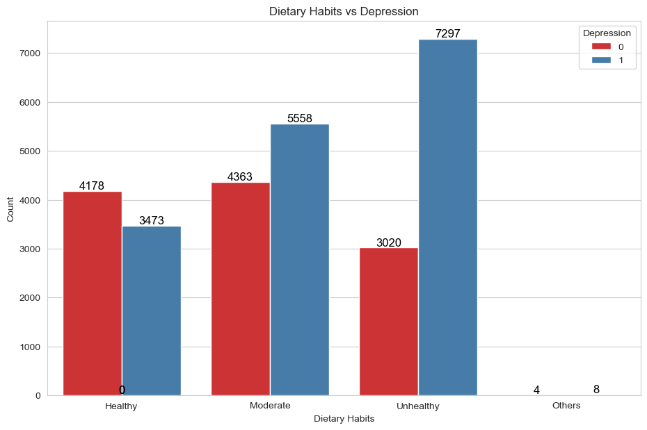

```python
plt.figure(figsize=(11,7))
ax = sns.countplot(x='Dietary Habits', hue='Depression', data=Depression, palette='Set1')

# Add count labels on top of each bar
for p in ax.patches:
    height = p.get_height()
    ax.annotate(f'{int(height)}',
                (p.get_x() + p.get_width() / 2., height),
                ha='center', va='center',
                fontsize=12, color='black',
                xytext=(0, 5), textcoords='offset points')

plt.title('Dietary Habits vs Depression')
plt.xlabel('Dietary Habits')
plt.ylabel('Count')
plt.legend(title='Depression')
plt.show()
```

Individuals with healthy dietary habits show a fairly balanced distribution between those with and without depression, while those with moderate and unhealthy dietary habits tend to have a higher number of individuals reporting depression. In particular, those with unhealthy dietary habits exhibit the highest number of people experiencing depression. On the other hand, the Others category has very few cases, both with and without depression.

# CATEGORICAL FEATURES

```python
from sklearn.preprocessing import LabelEncoder
```

```python
from sklearn.preprocessing import LabelEncoder

# List of categorical columns (you already have this part)
categorical_columns = ['Gender', 'City', 'Profession', 'Sleep Duration', 'Dietary Habits',
                       'Degree', 'Have you ever had suicidal thoughts', 'Family History of Mental Illness']

# Initialize LabelEncoder
le = LabelEncoder()

# Loop through each categorical column and apply LabelEncoder
for col in categorical_columns:
    if col in Depression.columns:  # Check if the column exists
        Depression[col] = le.fit_transform(Depression[col])

# Check that the columns are all converted
print(Depression.dtypes)
```

```
id                                         int64
Gender                                     int32
Age                                        int64
City                                       int32
Profession                                 int32
Academic Pressure                          int64
Work Pressure                              int64
CGPA                                     float64
Study Satisfaction                         int64
Job Satisfaction                           int64
Sleep Duration                             int32
Dietary Habits                             int32
Degree                                     int32
Have you ever had suicidal thoughts ?     object
Work/Study Hours                           int64
Financial Stress                         float64
Family History of Mental Illness           int32
Depression                                 int64
dtype: object
```

```python
# Convert 'Have you ever had suicidal thoughts ?' to numeric values (1 for 'Yes' and 0 for 'No')
Depression['Have you ever had suicidal thoughts ?'] = Depression['Have you ever had suicidal thoughts ?'].map({'Yes': 1, 'No': 0})

# Check the data types again
print(Depression.dtypes)

# Check the distribution of the 'Depression' column (class balance)
class_distribution = Depression['Depression'].value_counts(normalize=True)
print("Class distribution of 'Depression':")
print(class_distribution)
```

```
id                                         int64
Gender                                     int32
Age                                        int64
City                                       int32
Profession                                 int32
Academic Pressure                          int64
Work Pressure                              int64
CGPA                                     float64
Study Satisfaction                         int64
Job Satisfaction                           int64
Sleep Duration                             int32
Dietary Habits                             int32
Degree                                     int32
Have you ever had suicidal thoughts ?      int64
Work/Study Hours                           int64
Financial Stress                         float64
Family History of Mental Illness           int32
Depression                                 int64
dtype: object
Class distribution of 'Depression':
Depression
1    0.585499
0    0.414501
Name: proportion, dtype: float64
```

# TRAIN TEST SPLIT USING SKLEARN

```python
from sklearn.model_selection import train_test_split

# Split the dataset into train and test sets with stratification
X = Depression.drop(['Depression', 'id'], axis=1)
y = Depression['Depression']  # Target variable

X_train, X_test, y_train, y_test = train_test_split(X, y, test_size=0.3, random_state=42, stratify=y)
```

# TRAINING A DECISION TREE MODEL

```python
from sklearn.tree import DecisionTreeClassifier
```

# PREDICTION AND EVALUATION USING DECISION TREE

```python
from sklearn.tree import DecisionTreeClassifier
from sklearn.metrics import roc_auc_score, roc_curve
# Step 3: Initialize the Decision Tree model with class_weight='balanced'
dtree = DecisionTreeClassifier(random_state=42, class_weight='balanced')  # Adjust for imbalanced classes

# Step 4: Train the model on the training data
dtree.fit(X_train, y_train)

# Step 5: Make predictions on the test set
predictions = dtree.predict(X_test)

# Step 6: Evaluate the model's performance
print("Accuracy Score:", accuracy_score(y_test, predictions))  # Check overall accuracy
print("Confusion Matrix:\n", confusion_matrix(y_test, predictions))  # Check confusion matrix
print("Classification Report:\n", classification_report(y_test, predictions))  # Detailed metrics (precision, recall, etc.)

# Step 7: Calculate the AUC-ROC score
# Get predicted probabilities for the positive class (class 1)
y_probs = dtree.predict_proba(X_test)[:, 1]  # Get the probability for class 1

# Compute ROC AUC score
roc_auc = roc_auc_score(y_test, y_probs)
print("AUC-ROC Score:", roc_auc)
```

```
Accuracy Score: 0.7706367220164855
Confusion Matrix:
 [[2489  981]
 [ 939 3962]]
Classification Report:
               precision    recall  f1-score   support

           0       0.73      0.72      0.72      3470
           1       0.80      0.81      0.80      4901

    accuracy                           0.77      8371
   macro avg       0.76      0.76      0.76      8371
weighted avg       0.77      0.77      0.77      8371

AUC-ROC Score: 0.7628487569730815
```

# PREDICTION AND EVALUATION USING RANDOM FOREST

```python
from sklearn.ensemble import RandomForestClassifier
from sklearn.metrics import accuracy_score, classification_report, confusion_matrix
```

```python
# Initialize Random Forest Classifier
rf = RandomForestClassifier(n_estimators=300, random_state=42, class_weight='balanced')  # You can adjust parameters
```

```python
# Train the Random Forest model
rf.fit(X_train, y_train)
```

```
RandomForestClassifier(class_weight='balanced', n_estimators=300,
                       random_state=42)
```

```python
# Make predictions on the test set
rf_predictions = rf.predict(X_test)
```

```python
# Evaluate the model
print("Accuracy:", accuracy_score(y_test, rf_predictions))  # Accuracy score
print("Confusion Matrix:\n", confusion_matrix(y_test, rf_predictions))  # Confusion matrix
print("Classification Report:\n", classification_report(y_test, rf_predictions))  # Precision, Recall, F1-Score
# Step 5: Compute AUC-ROC score
rf_probs = rf.predict_proba(X_test)[:, 1]  # Get probability for class 1
roc_auc = roc_auc_score(y_test, rf_probs)
# Compute ROC AUC score
print("AUC-ROC Score:", roc_auc)
```

```
Accuracy: 0.8421932863457173
Confusion Matrix:
 [[2689  781]
 [ 540 4361]]
Classification Report:
               precision    recall  f1-score   support

           0       0.83      0.77      0.80      3470
           1       0.85      0.89      0.87      4901

    accuracy                           0.84      8371
   macro avg       0.84      0.83      0.84      8371
weighted avg       0.84      0.84      0.84      8371

AUC-ROC Score: 0.9182840413089841
```

# PREDICTION AND EVALUATION USING LASSO REGRESSION

```python
from sklearn.linear_model import LogisticRegression
from sklearn.metrics import classification_report, confusion_matrix, accuracy_score

# Define Lasso (Logistic Regression with L1 regularization)
lasso_model = LogisticRegression(penalty='l1', solver='saga', class_weight='balanced', random_state=42)

# Train the model on the training data
lasso_model.fit(X_train, y_train)

# Make predictions on the test data
predictions = lasso_model.predict(X_test)

# Print the classification report
print(classification_report(y_test, predictions))

# Print the confusion matrix
print(confusion_matrix(y_test, predictions))

# Print the accuracy score
print(accuracy_score(y_test, predictions))
# Compute ROC AUC score
roc_auc = roc_auc_score(y_test, predictions)
print("AUC-ROC Score:", roc_auc)
```

```
              precision    recall  f1-score   support

           0       0.80      0.84      0.82      3470
           1       0.88      0.85      0.87      4901

    accuracy                           0.85      8371
   macro avg       0.84      0.84      0.84      8371
weighted avg       0.85      0.85      0.85      8371

[[2906  564]
 [ 723 4178]]
0.8462549277266754
AUC-ROC Score: 0.8449715314230407
```